# Data, Big or Otherwise, in the Insurance Industry

Mick Cooney mcooney@agrippadataconsulting.com

27 February 2018

# Who Am I?

Physics

Quant Finance

Statistics

Computer Programming

Nerd

[figure not shown]

## The Last Three Years…

- Lapse Modelling – Survival analysis
- Geospatial Modelling – PostgreSQL / PostGIS
- Customer Segmentation – Hierarchical clustering
- Mortality Swaps – MonteCarlo simulation
- Underwriting Fraud – Bayesian networks
- Data Generation – Life/Motor/Captive/Employer/Corporate
- Car Insurance Pricing – GLMs / MonteCarlo simulation
- Reinsurance Loss Modelling – Bayesian Hierarchical / Stan
- Email Analysis – NLP / LDA
- Property Insurance Loss Costing – Stan / Boosting / Dataviz

# What is (Big) Data?

## Dirty Little Secret

You (Probably) Do Not Have a Big Data Problem

## Sizes of Data

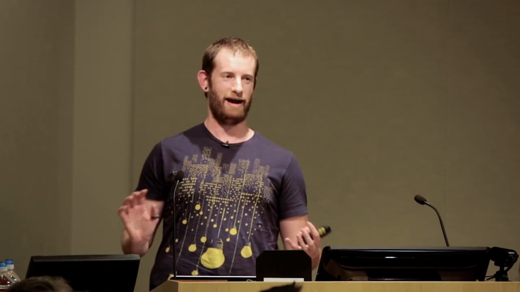

Hadley Wickham’s Interview with a Data Scientist

Peadar Coyle

### Three Data Sizes

In-Memory

On-Disk

Multi-Disk

## Three Problem Sizes

Sampleable Problems

Parallelisable Problems

Irreducible Problems

### Sampleable Problems

$\sim$ 90% of problems

### Parallelisable Problems

$\sim$ 9% of problems

### Irreducible Problems

$\sim$ 1% of problems

# What Does Big Data Mean?

Various definitions

Generally bigger than one machine

## Cynical Definition

“Big Data” is a marketing term used by salespeople to extract large sums of money from companies with a severe case of FOMO.

## Circular Definition

A big data problem is one where big data solutions work best

## Practical Definition

Software infrastructure to assist in the processing and use of large datasets

# Data in Insurance

Most classic insurance problems are small data

## Actuarial Problems

Pricing

Reserving

Capital Modelling

### Loss-Costing DNF Business

5-10k Policies

SoV data can be large

Claim data poor quality

### Estimating Claims Reserves

Estimate total claim amounts

Data sparse

Chain Ladder often ineffective

### ICT Pricing

Exposure data aggregated

Partial view of claims (censored)

### Cost of Guarantees

With-profit Funds

Quant finance

MonteCarlo simulation

### Estimating Lapse Risk

Customer segmentation

Survival analysis

## Other Problems

Less traditionally ‘actuarial’

### Marketing Campaigns

Limited marketing budget

Optimise call list

### Underwriting Fraud

Most data missing

Find fraudulent or misleading applications

### Internal Operations

Communications data, emails

Identify bottlenecks

Improve customer turnaround

## Some Predictions

- Catastrophe Modelling
- Uplift Modelling / Marketing Evaluation
- Lapse Modelling (Churn)
- Mortality Modelling
- Risk Modelling and Reserving
- Fraud Investigation
- Internal Communications
- Compliance

# Getting Started

## Suggested Learning

- SQL
- Linear Algebra
- Statistics
- Computer Programming
- Source Control
- Linear Models
- Tree-based Models

## Suggested Activities

[figure not shown]

[figure not shown]

[figure not shown]

[figure not shown]

## Where to Learn

[figure not shown]

[figure not shown]

[figure not shown]

[figure not shown]

Help everyone you can!

# Thank You

## Get in Touch

mcooney@agrippadataconsulting.com

GitHub: http://www.github.com/kaybenleroll